# EDA: summary statistics

CMSC320

2016-09-27

Let’s continue our discussion of Exploratory Data Analysis. In the previous section we saw ways of visualizing data (variables) using plots to start understanding properties of how data is distributed, an essential and preliminary step in data analysis. In this section, we start discussing statistical, or numerical, summaries of data to quantify properties that we observed using visual summaries and representations.

Remember that one purpose of EDA is to spot problems in data (as part of data wrangling) and understand variable properties like:

- central trends (mean)
- spread (variance)
- skew
- suggest possible modeling strategies (e.g., probability distributions)

We also want to use EDA to understand relationship between pairs of variables, e.g. their correlation or covariance.

One last note on EDA. John W. Tukey was an exceptional scientist/mathematician, who had profound impact on statistics and Computer Science. A lot of what we cover in EDA is based on his groundbreaking work. I highly recommend you read more about him: https://www.stat.berkeley.edu/~brill/Papers/life.pdf.

### Range

Part of our goal is to understand how variables are distributed in a given dataset. Note, again, that we are not using *distributed* in a formal mathematical (or probabilistic) sense. All statements we are making here are based on data at hand, so we could refer to this as the *empirical distribution* of data. Here, *empirical* is used in the sense that this is data resulting from an experiment.

Let’s use a dataset on diamond characteristics as an example.

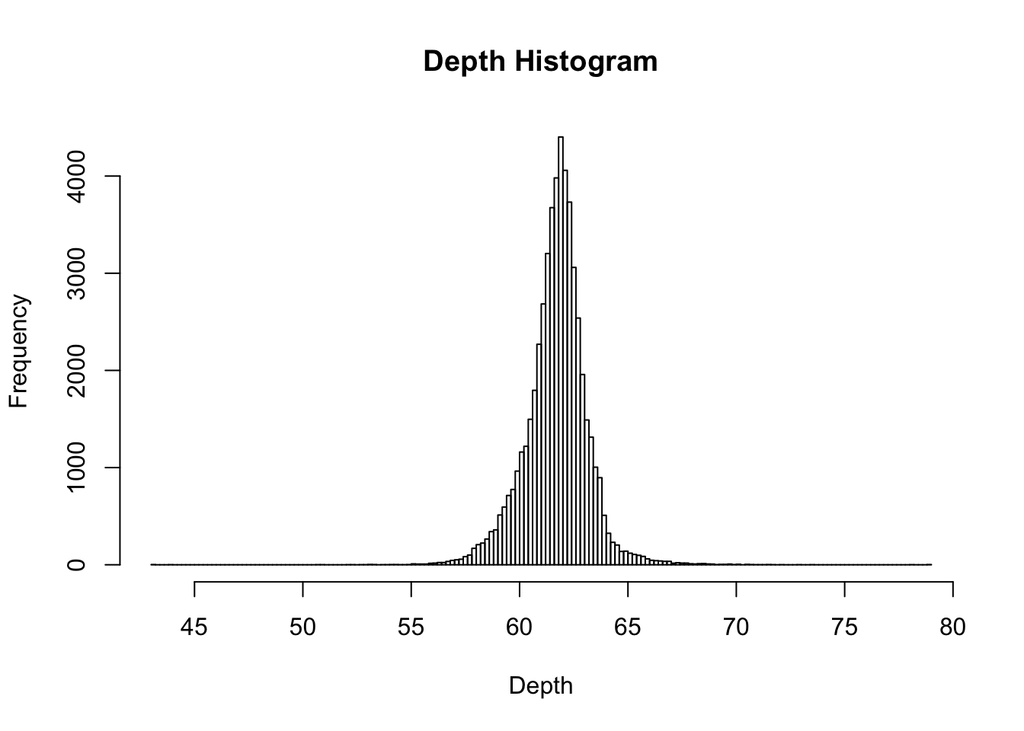

```r
library(ggplot2)
data(diamonds)
library(dplyr)

hist(diamonds$depth, main="Depth Histogram", xlab="Depth", nclass=200)
```

(Here’s some help interpreting these variables: https://en.wikipedia.org/wiki/Diamond_(gemstone)#Gemological_characteristics).

Let’s start using some notation to make talking about this a bit more efficient. We assume that we have data across $n$ entitites (or observational units) for $p$ attributes. In this dataset $n=53940$ and $p=10$. However, let’s consider a single attribute, and denote the data for that attribute (or variable) as $x_1, x_2, \ldots, x_n$.

Ok, so what’s the first question we want to ask about how data is distributed? Since we want to understand how data is distributed across a *range*, we should first define the range.

[output not shown]

We use notation $x_{(1)}$ and $x_{(n)}$ to denote the minimum and maximum statistics. In general, we use notation $x_{(q)}$ for the rank statistics, e.g., the $q$th largest value in the data.

### Central Tendency

Now that we know the range over which data is distributed, we can figure out a first summary of data is distributed across this range. Let’s start with the *center* of the data: the *median* is a statistic defined such that half of the data has a smaller value. We can use notation $x_{(n/2)}$ (a rank statistic) to represent the median. Note that we can use an algorithm based on the quicksort partition scheme to compute the median (on average) in linear time.

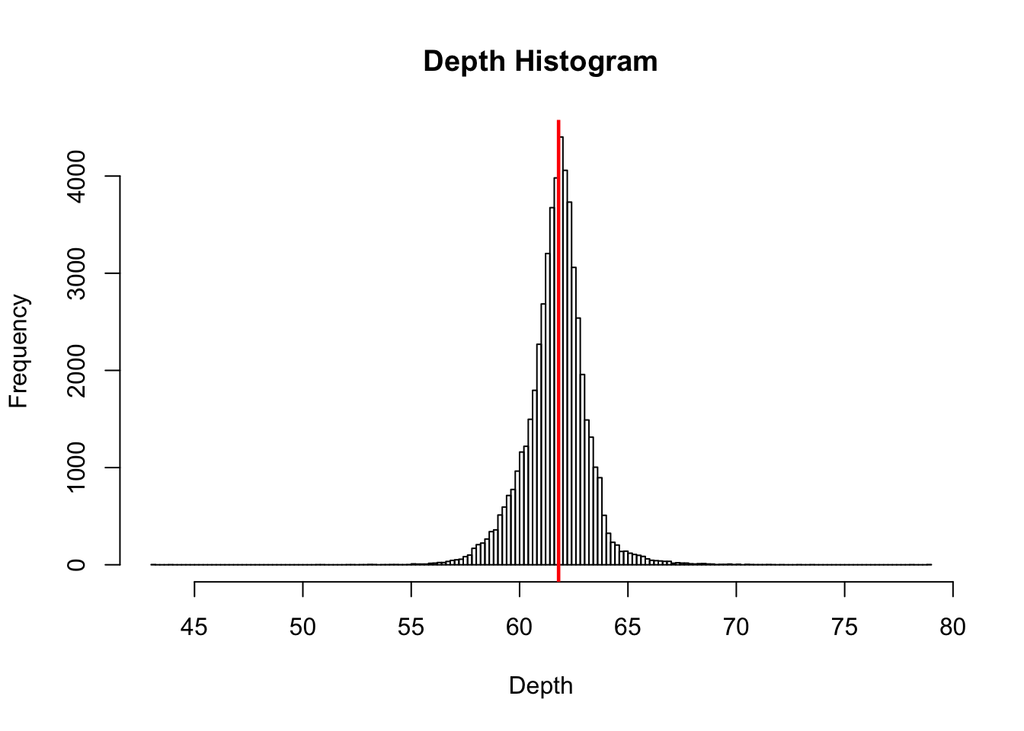

```r
median_depth <- median(diamonds$depth)

hist(diamonds$depth, main="Depth Histogram", xlab="Depth", nclass=200)
abline(v=median_depth, lwd=2.3, col="red")
```

### Derivation of the mean as central tendency statistic

Of course, the best known statistic for central tendency is the *mean*, or average of the data: $\overline{x} = \frac{1}{n} \sum_{i=1}^n x_i$. It turns out that in this case, we can be a bit more formal about “center” means in this case. Let’s say that the *center* of a dataset is a point in the range of the data that is *close* to the data. To say that something is *close* we need a measure of *distance*.

So for two points $x_1$ and $x_2$ what should we use for distance? We should base it on $(x_1 - x_2)$ but that’s not enough since its sign depends on the order in which we write it. Using the absolute value solves that problem $|x_1 - x_2|$ since now the sign doesn’t matter, but this has some issues that we will see later. So, next best thing we can do is use the square of the difference. So, in this case, the distance between data point $x_1$ and $x_2$ is $(x_1 - x_2)^2$. Here is a fun one: what’s the largest distance between two points in our dataset?

So, to define the *center*, let’s build a criterion based on this distance by adding this distance across all points in our dataset:

$$RSS(\mu) = \frac{1}{2} \sum_{i=1}^n (x_i - \mu)^2$$

Here RSS means *residual sum of squares*, and we $\mu$ to stand for candidate values of *center*. We can plot RSS for different values of $\mu$:

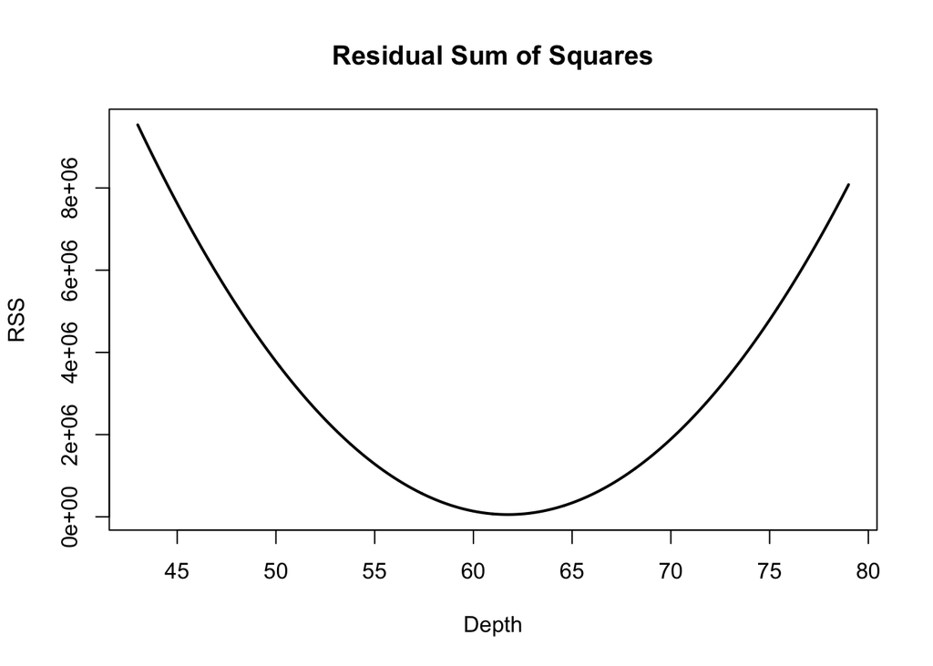

```r
rss <- function(mu) { 0.5 * sum((diamonds$depth - mu)^2)}
mu_candidates <- seq(min(diamonds$depth), max(diamonds$depth), len=1000)
plot(mu_candidates, sapply(mu_candidates, rss), xlab="Depth", ylab="RSS", type="l", lwd=2, main="Residual Sum of Squares")
```

Now, what should our “center” estimate be? We want a value that is *close* to the data based on RSS! So we need to find the value in the range that minimizes RSS. From calculus, we know that a necessary condition for the minimizer $\hat{\mu}$ of RSS is that the derivative of RSS is zero at that point. So, the strategy to minimize RSS is to compute its derivative, and find the value of $\mu$ where it equals zero.

So, let’s find the derivative of RSS:

$$\begin{eqnarray}
\frac{\partial}{\partial \mu} \frac{1}{2} \sum_{i=1}^n (x_i - \mu)^2 & = & \frac{1}{2} \sum_{i=1}^n \frac{\partial}{\partial \mu} (x_i - \mu)^2 \\
{} & = & \frac{1}{2} \sum_{i=1}^n 2(x_i - \mu) \times \frac{\partial}{\partial \mu} (x_i - \mu) \\
{} & = & \frac{1}{2} \sum_{i=1}^n 2(x_i - \mu) \times (-1) \\
{} & = & \frac{1}{2} 2 \sum_{i=1}^n (\mu - x_i) \\
{} & = & \sum_{i=1}^n \mu - \sum_{i=1}^n x_i \\
{} & = & n\mu - \sum_{i=1}^n x_i
\end{eqnarray}$$

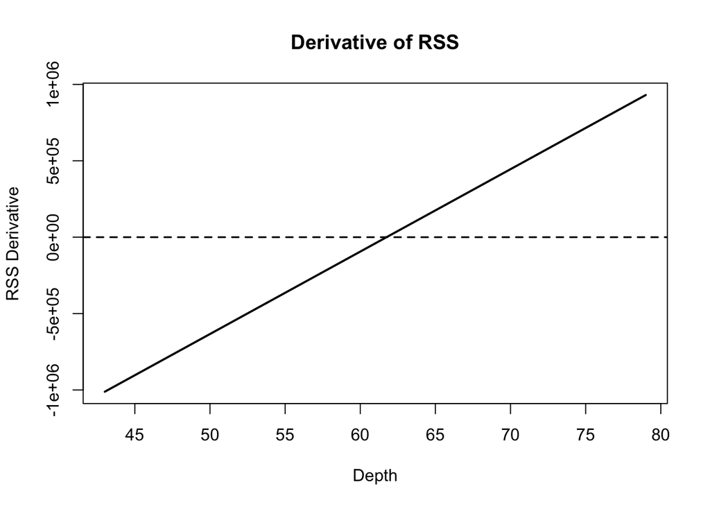

```r
rss_deriv <- function(mu) { nrow(diamonds)*mu - sum(diamonds$depth)}
plot(mu_candidates, sapply(mu_candidates, rss_deriv), xlab="Depth", ylab="RSS Derivative", type="l", lwd=2, main="Derivative of RSS")
abline(h=0,lty=2,lwd=1.6)
```

Next, we set that equal to zero and find the value of $\mu$ that solves that equation:

$$\begin{eqnarray}
\frac{\partial}{\partial \mu} & = & 0 & \Rightarrow \\
n\mu - \sum_{i=1}^n x_i & = & 0 & \Rightarrow \\
n\mu & = & \sum_{i=1}^n x_i & \Rightarrow \\
\mu & = & \frac{1}{n} \sum_{i=1}^n x_i & {}
\end{eqnarray}$$

That’s the average we know and love! So the fact you should remember:

**The mean is the value that minimizes RSS for a dataset**

It equals the value where the derivative of RSS is 0:

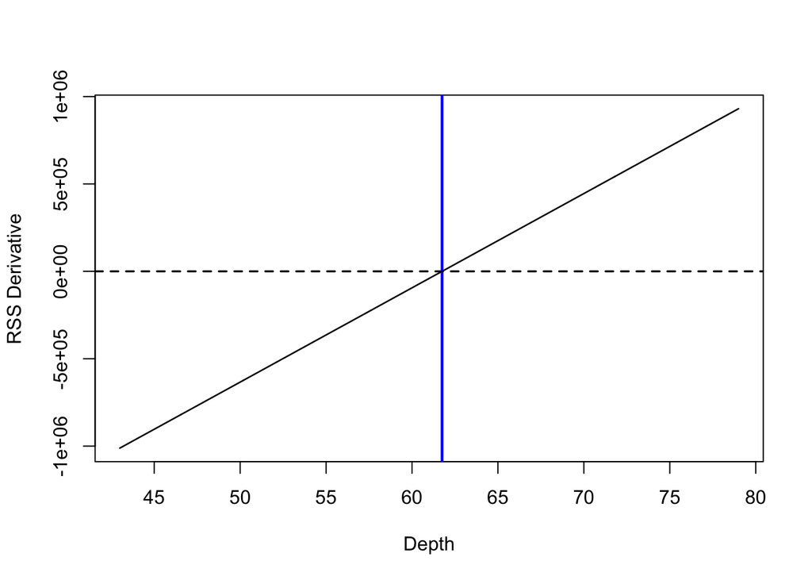

```r
our_mean <- sum(diamonds$depth) / nrow(diamonds)
plot(mu_candidates, sapply(mu_candidates, rss_deriv), xlab="Depth", ylab="RSS Derivative", type="l", lwd=1.3)
abline(v=our_mean, lwd=2.3, col="blue")
abline(h=0, lty=2, lwd=1.6)
```

It is the value that minimizes RSS:

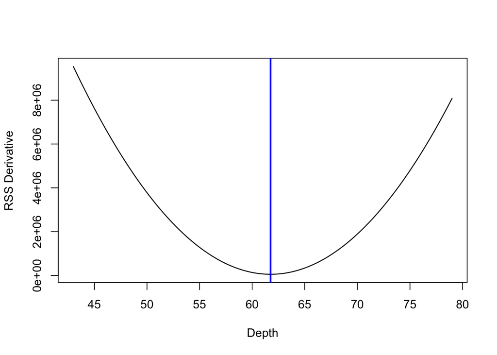

```r
plot(mu_candidates, sapply(mu_candidates, rss), xlab="Depth", ylab="RSS Derivative", type="l", lwd=1.3)
abline(v=our_mean, lwd=2.3, col="blue")
```

And it serves as an estimate of central tendency of the dataset:

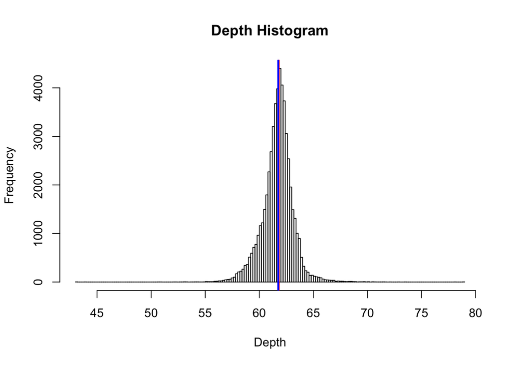

```r
hist(diamonds$depth, main="Depth Histogram", xlab="Depth", nclass=200)
abline(v=median_depth, lwd=2.3, col="red")
abline(v=our_mean, lwd=2.3, col="blue")
```

Note that in this dataset the mean and median are not exactly equal, but are very close:

```r
diamonds %>%
  summarize(mean_depth = mean(depth), median_depth = median(depth))
```

```
## # A tibble: 1 × 2
##   mean_depth median_depth
##        <dbl>        <dbl>
## 1    61.7494         61.8
```

One last note, there is a similar argument to define the median as a measure of *center*. In this case, instead of using RSS we use a different criterion: the sum of absolute deviations $\sum_{i=1}^n |x_i - m|$. The median is the minimizer of this criterion.

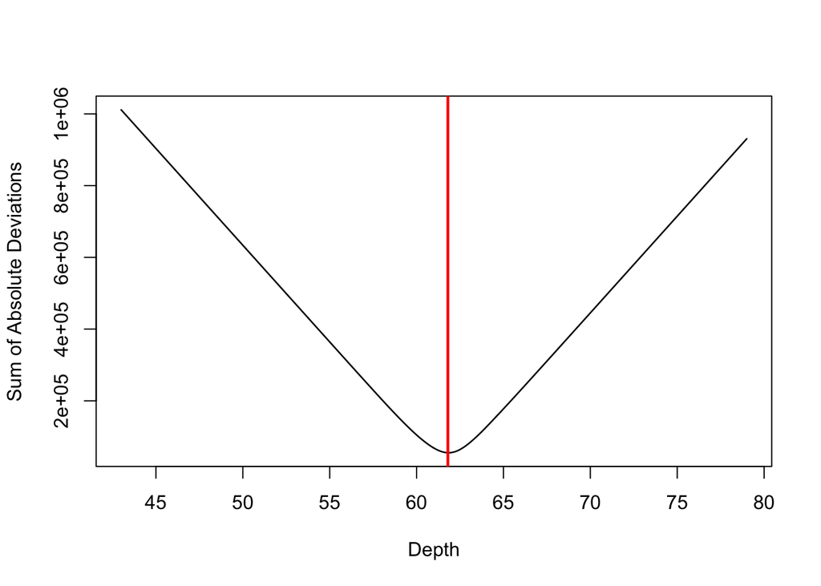

```r
sad <- function(m) sum(abs(diamonds$depth - m))
plot(mu_candidates, sapply(mu_candidates, sad), xlab="Depth", ylab="Sum of Absolute Deviations", type="l", lwd=1.3)
abline(v=median(diamonds$depth), lwd=2.3, col="red")
```

### Spread

Now that we have a measure of center, we can now discuss how data is *spread* around that center. For the mean, we have a convenient way of describing this: the average distance (using squared difference) from the mean. We call this the *variance* of the data:

$$\mathrm{var}(x) = \frac{1}{n} \sum_{i=1}^n (x_i - \overline{x})^2$$

You will also see it with a slightly different constant in the front for technical reasons that we may discuss later on:

$$\mathrm{var}(x) = \frac{1}{n-1} \sum_{i=1}^n (x_i - \overline{x})^2$$

Variance is a commonly used statistic for spread but it has the disadvantage that its units are not easy to conceptualize (e.g., squared diamond depth). A spread statistic that is in the same units as the data is the *standard deviation*, which is just the squared root of variance:

$$\mathrm{sd}(x) = \sqrt{\frac{1}{n}\sum_{i=1}^n (x_i - \overline{x})^2}$$

We can also use *standard deviations* as an interpretable unit of how far a given data point is from the mean:

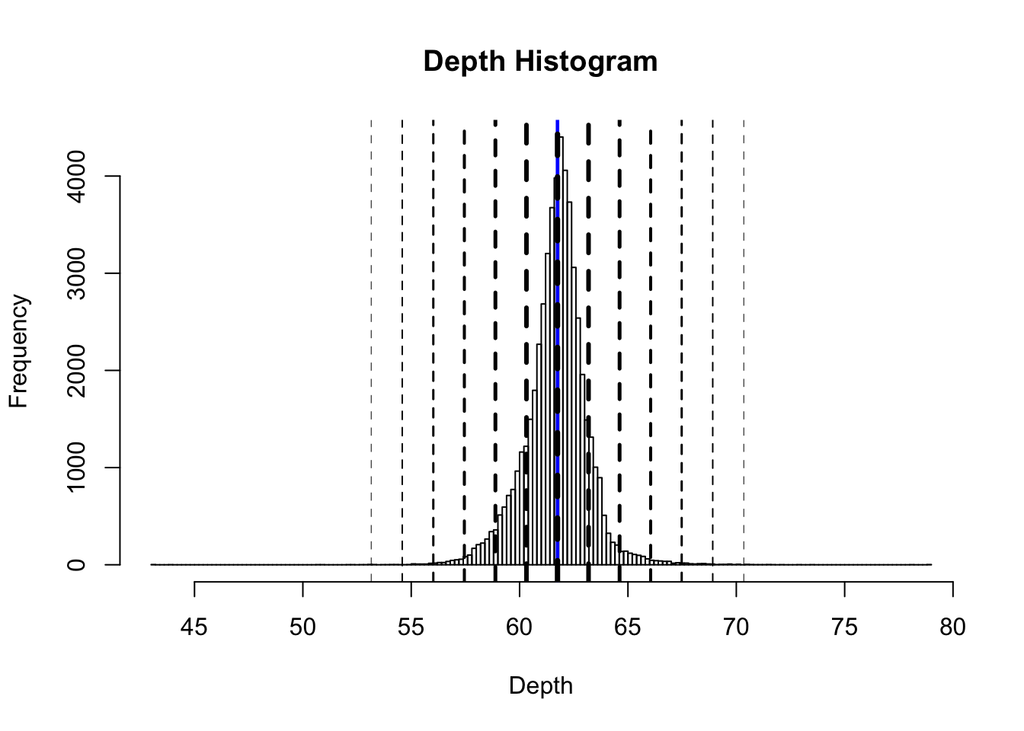

```r
mean_depth <- mean(diamonds$depth)
sd_depth <- sd(diamonds$depth)

hist(diamonds$depth, main="Depth Histogram", xlab="Depth", nclass=200)
abline(v=mean_depth, lwd=2.3, col="blue")
abline(v=mean_depth + sd_depth * seq(-6,6), lty=2, lwd=3.5-abs(seq(-3,3,len=13)))
```

As a rough guide, we can use “standard deviations away from the mean” as a measure of spread as follows:

[output not shown]

We will see later how these rough approximations are derived from a mathematical assumption about how data is distributed *beyond* the data we have at hand.

### Spread estimates using rank statistics

Just like we saw how the median is a rank statistic used to describe central tendency, we can also use rank statistics to describe spread. For this we use two more rank statistics: the first and third *quartiles*, $x_{(n/4)}$ and $x_{(3n/4)}$ respectively:

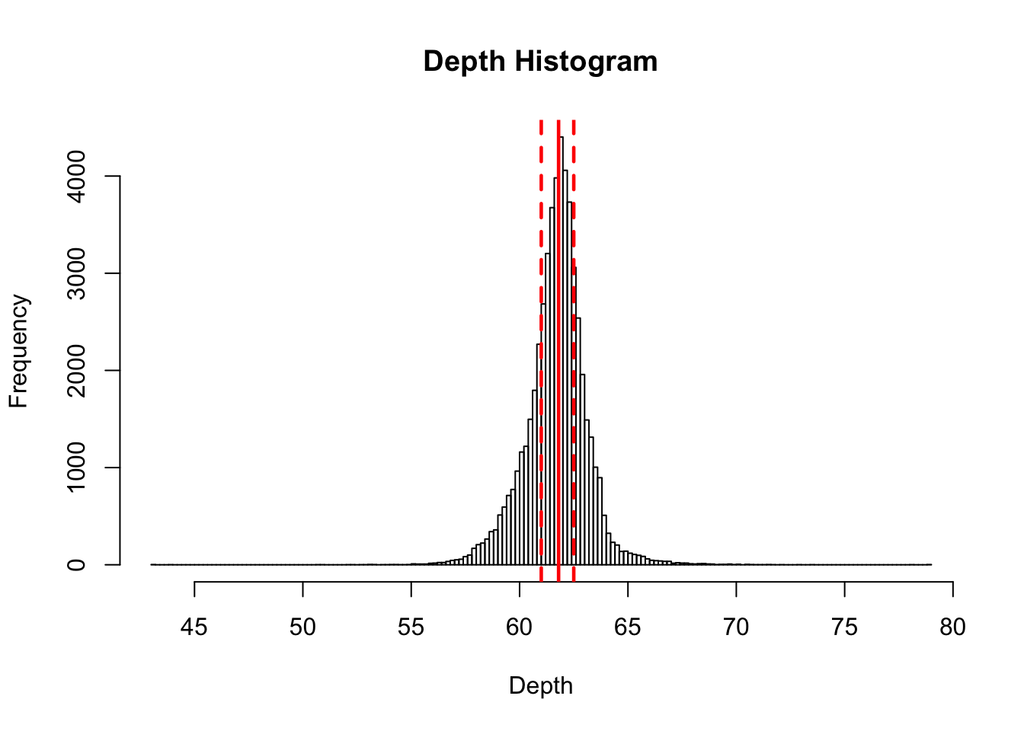

```r
first_quartile <- quantile(diamonds$depth, p=1/4)
third_quartile <- quantile(diamonds$depth, p=3/4)

hist(diamonds$depth, main="Depth Histogram", xlab="Depth", nclass=200)
abline(v=median_depth, lwd=2.3, col="red")
abline(v=c(first_quartile, third_quartile), lwd=2.3, col="red", lty=2)
```

Note, the five order statistics we have seen so far: minimum, maximum, median and first and third quartiles are so frequently used that this is exactly what `R` uses by default as a `summary` of a numeric vector of data (along with the mean):

```r
summary(diamonds$depth)
```

```
##    Min. 1st Qu.  Median    Mean 3rd Qu.    Max.
##   43.00   61.00   61.80   61.75   62.50   79.00
```

This five-number summary are also all of the statistics used to construct a boxplot to summarize data distribution.

### Inter-quartile range

```r
diamonds %>%
  summarize(sd_depth = sd(depth), iqr_depth = IQR(depth))
```

```
## # A tibble: 1 × 2
##   sd_depth iqr_depth
##      <dbl>     <dbl>
## 1 1.432621       1.5
```

## Skew

One last thought. Although there are formal ways of defining this precisely, the five-number summary can be used to understand if data is skewed. How? Consider the differences between the first and third quartiles to the median:

```r
first_difference <- median_depth - first_quartile
third_difference <- third_quartile - median_depth
c(first_difference, third_difference)
```

```
## 25% 75%
## 0.8 0.7
```

If one of these differences is larger than the other, then that indicates that this dataset might be skewed, that is, that the range of data on one side of the median is longer (or shorter) than the range of data on the other side of the median. Do you think our diamond depth dataset is skewed?

## Covariance and correlation

The scatter plot is a visual way of observing relationships between pairs of variables. Like descriptions of distributions of single variables, we would like to construct statistics that summarize the relationship between two variables quantitatively. To do this we will extend our notion of *spread* (or variation of data around the mean) to the notion of *co-variation*: do pairs of variables vary around the mean in the same way.

Consider now data for two variables over the same $n$ entities: $(x_1,y_1), (x_2,y_2), \ldots, (x_n,y_n)$. For example, for each diamond, we have `carat` and `price` as two variables:

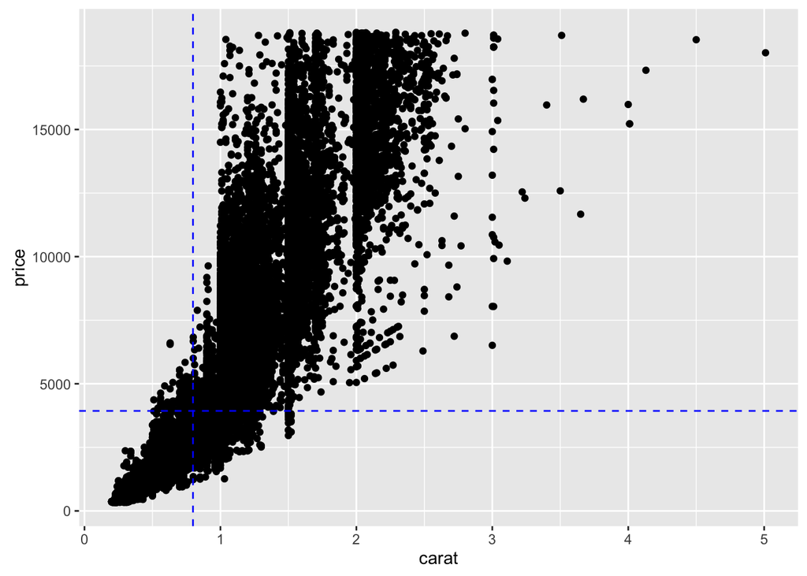

```r
diamonds %>%
  ggplot(aes(x=carat, y=price)) +
    geom_point() +
    geom_hline(aes(yintercept = mean(price)), color="blue", lty=2) +
    geom_vline(aes(xintercept = mean(carat)), color="blue", lty=2)
```

We want to capture the relationship: $x_i$ varies in the same direction and scale away from its mean as $y_i$. This leads to *covariance*

$$cov(x,y) = \frac{1}{n} \sum_{i=1}^n (x_i - \overline{x})(y_i - \overline{y})$$

Think of what would the covariance for $x$ and $y$ be if $x_i$ varies in the *opposite* direction as $y_i$?

Just like variance, we have an issue with units and interpretation for covaraince, so we introduce *correlation* (formally, Pearson’s correlation coefficient) to summarize this relationship in a *unit-less* way:

$$cor(x,y) = \frac{cov(x,y)}{sd(x) sd(y)}$$

As before, we can also use rank statistics to define a measure of how two variables are associated. One of these, *Spearman correlation* is commonly used. It is defined as the Pearson correlation coefficient of the ranks (rather than actual values) of pairs of variables.